# What’s happening in Mali?

Tom Brailey

## Introduction

After conducting extensive research into Mali’s political system for my senior thesis, I have been staying up to date with Mali’s current events. One particular event stuck out for me in 2021. This was a report on the Russian paramilitary group Wagner operating in Mali, and the Mali government announcing it’s support for their intervention. The Mali government even went so far as to proclaim their preference for Wagner’s operations over the French military, who, even now, are slowly withdrawing their troops from the region. I was struck by how overt, and how positively-received (at least by the hosts), this display of foreign intervention was, and I wanted to learn more about the Wagner group, and foreign paramilitary movements more generally.

## Exploratory analysis

I started by downloading ACLED data on conflict types in Africa. ACLED provides information on paramilitary groups (you can see Wagner come up a bunch of times), but it doesn’t provide explicit information on the country of origin of these paramilitary groups. So the first step is to download the data and back out these countries of origin. To learn more about my (very much a work in progress) country finder function, read about it [here](https://tjbrailey.netlify.app/posts/finding_a_country/).

```r
# Let's load our essential packages
library(magrittr)
library(ggplot2)
library(rvest)
library(httr)
library(data.table)

# Source our country-finder function
source(paste0(here::here(), "/content/find_country.R"))

# Read in shapefile data
world_map <- rnaturalearth::ne_countries(scale = "medium", type = "map_units", returnclass = "sf")
world_map %<>% dplyr::mutate(country = countrycode::countryname(sourcevar = name))
# Set up googlesheets connection
googlesheets4::gs4_deauth()

# ACLED data
acled <-
  read.csv2(
    paste0(
      here::here(),
      "/public/posts/2019-01-29-2022-02-02-Eastern_Africa-Middle_Africa-Northern_Africa-Southern_Africa-Western_Africa.csv"),
    sep = ";")

# Get a list of countries from acled
countries_acled <- readRDS(paste0(here::here(), "/public/posts/acled_countries.rds"))
countries_acled <- countries_acled$Country
countries_acled <- sub(" \\(.*| of | & | and | the |  ", " ", countries_acled)
countries_acled <- sub(" \\(.*| of | & | and | the |  ", " ", countries_acled)
countries_acled <- unique(countries_acled)
countries_acled <- sort(countries_acled, decreasing = TRUE)
```

```r
# Create a new column that contains information in parentheses in the actor1 column
acled %<>%
  dplyr::mutate(
    actor1_location_temp = stringr::str_extract_all(
      string = actor1, pattern = "\\([^()]+\\)", simplify = FALSE),
    actor1_location_temp = stringr::str_remove_all(
      string = actor1_location_temp,
      pattern = "\\(|\\)|\\-|\\d+|\\W\\W|character")) %>%
  dplyr::mutate(
    actor1_location = countrycode::countryname(
      sourcevar = actor1_location_temp))

# Return a list of missing locations to manually investigate
actor1_missing_locations <- acled$actor1[is.na(acled$actor1_location)]
actor1_missing_locations <- tibble::as_tibble(unique(actor1_missing_locations[actor1_missing_locations != ""]))

# Individual examples
find_country(name = "Oyo State Park Management System") # should be Nigeria
find_country(name = "TPLF: Tigray People's Liberation Front") # Should be Ethiopia
find_country(name = "CNDD-FDD-Imbonerakure: National Council for the Defence of Democracy (Imbonerakure Faction)") # Should be Burundi
find_country(name = "Wagner group") # Should be Russia
find_country(name = "Levelling up") # Should be United Kingdom
find_country(name = "Mayi Mayi Militia") # Should be DRC

# Use our (WIP) country finder function
actor1_missing_locations$guess <- lapply(X = actor1_missing_locations$value, FUN = find_country)

# Join data
joined <- dplyr::left_join(acled, actor1_missing_locations, by = c("actor1" = "value")) %>%
  dplyr::mutate(guess = sapply(guess, toString),
                guess = ifelse(guess == "", NA, guess),
                guess = countrycode::countryname(sourcevar = guess),
                actor1_location  = dplyr::coalesce(guess, actor1_location),
                country = countrycode::countryname(sourcevar = country)) %>%
  dplyr::select(-actor1_location_temp, -guess)
```

Okay, so we have created a new variable that is our best guess of the country of origin of the paramilitary groups that are involved in instances of conflict in Africa. Now let’s ensure that we have all the relevant coordinates that will allow us to create a flow map.

```r
sf::sf_use_s2(FALSE)

# Dataset of country locations
origin_locations <- world_map %>%
  dplyr::select(name, country, geometry) %>%
  dplyr::filter(!is.na(country)) %>%
  dplyr::mutate(
    centroid = sf::st_centroid(.),
    orig_lon = sf::st_coordinates(centroid)[,1],
    orig_lat = sf::st_coordinates(centroid)[,2]) %>%
  dplyr::rename(actor1_location = country)

# Join to main acled dataset
to_save <- joined %>%
  dplyr::left_join(., origin_locations, by = "actor1_location") %>%
  sf::st_as_sf(.) %>%
  dplyr::mutate(latitude = as.numeric(latitude),
                longitude = as.numeric(longitude))

# Save dataset so we don't have to keep running intensive code
saveRDS(object = to_save, file = paste0(here::here(), "/content/acled_prepped.rds"))

# Remove intermediary datasets
rm(acled, actor1_missing_locations, joined, locations, to_save)
```

Now the data are ready, let’s plot a flow map:

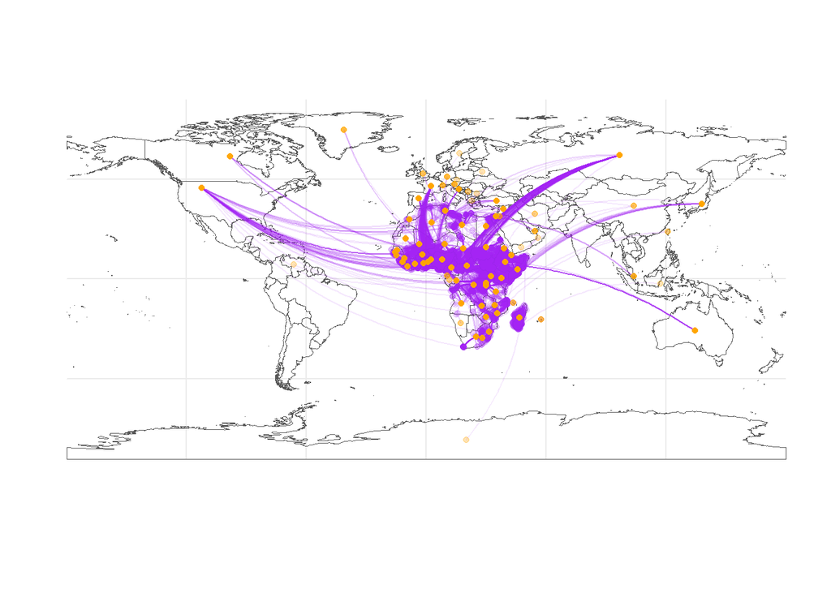

```r
# Re-read data back in for convenience
dat <- readRDS(file = paste0(here::here(), "/content/acled_prepped.rds"))

# Plot
plot <- ggplot() +
  geom_sf(data = world_map, fill = NA) +
  geom_curve(
    data = dat,
    color = "purple",
    alpha = 0.1,
    curvature = 0.2,
    aes(
      x = orig_lon,
      y = orig_lat,
      xend = longitude,
      yend = latitude)) +
  geom_point(data = dat, mapping = aes(x = longitude, y = latitude), color = "purple", alpha = 0.1, show.legend = TRUE) +
  geom_point(data = dat, mapping = aes(x = orig_lon,  y = orig_lat), color = "orange", alpha = 0.3, show.legend = TRUE) +
  labs(x = "", y = "") +
  theme_minimal()
plot
```

It’s a bit busy, but you can glean from this plot that the majority of foreign militias are coming from *within* Africa, but that the US and Russia have their fingers in many conflict pies so to speak. Since I wanted to look into Russian paramilitaries in particular, let’s look just at African conflicts with Russian involvement:

```r
# Subset to include only African states with Russian intervention
ac1_russia <- dat %>%
  dplyr::filter(actor1_location == "Russia")

russia_int <- unique(ac1_russia$country)

world_map_sub <- dplyr::filter(world_map, continent %in% c("Europe", "Africa"))

world_map_sub$russia_int <- ifelse(world_map_sub$country %in% c(russia_int), 1, 0)

# Plot African states with Russian intervention
ggplot() +
  geom_sf(data = world_map_sub, mapping = aes(fill = factor(russia_int))) +
  scale_fill_manual(values = c("0" = "white", "1" = "black"), labels = c("No", "Yes")) +
  geom_point(data = ac1_russia, mapping = aes(x = longitude, y = latitude), alpha = 0.3, color = "purple") +
  coord_sf(xlim = c(-20, 60), ylim = c(-30, 35)) +
  labs(x = "", y = "", fill = "Russian involvement?") +
  theme_minimal()
```

[output not shown]

## Conclusion

The Wagner Group appears to be expanding its presence across African states. Under the guise of providing efficient and cheap solutions to domestic issues, their actual functionalities and reach appears to be far broader. Wide reports of mis-information campaigns in CAR and involvement in anti-government operations in Libya suggests that their role in Africa is not simply that of a private military company. They may be, in fact, simply an extension of the Russian military, and a vehicle for Russian influence in the region.